# R Notebook

# Prediction Activity

A mini-prediction competition. Who can produce the best model to predict pass/fail

```r
#install.packages('caret')
library(caret)
library(tidyverse)
library(GGally)
```

### Download

- Download the Open University Learning Analytics dataset from [here](https://analyse.kmi.open.ac.uk/open_dataset)
- Import the `studentVle.csv`, `studentAssessment.csv` and `studentInfo.csv` files into R

```r
vle <- read.csv("data/studentVle.csv")
assessment <- read.csv("data/studentAssessment.csv")
info <- read.csv("data/studentInfo.csv")
```

### Wrangling

- Calculate the average daily number of clicks (site interactions) for each student from the `studentVle` dataset

```r
vle_clicks_mean <- vle %>%
  group_by(.data$id_student, date) %>%
  summarise(sum_clicks = sum(.data$sum_click, na.rm = TRUE)) %>%
  ungroup() %>%
  group_by(.data$id_student) %>%
  summarise(mean_clicks = mean(.data$sum_clicks, na.rm = TRUE))
```

- Calculate the average assessment score for each student from the `studentAssessment` dataset

```r
assessment_score_mean <- assessment %>%
  group_by(.data$id_student) %>%
  summarise(mean_score = mean(.data$score, na.rm = TRUE))
```

- Merge your click and assessment score average values into the `studentInfo` dataset

```r
joined_data <- left_join(info, vle_clicks_mean, by = "id_student") %>%
  left_join(assessment_score_mean, by = "id_student")
```

### Explore

- Generate summary statistics for the variable `final_result`

```r
table(joined_data$final_result)
```

```
Distinction        Fail        Pass   Withdrawn
       3024        7052       12361       10156
```

```r
anyNA(joined_data$final_result)
```

```
[1] FALSE
```

- Ensure that the final_result variable is binary (Remove all students who withdrew from a courses and convert all students who recieved distinctions to pass)

```r
joined_data <- filter(joined_data, .data$final_result != "Withdrawn")

joined_data["final_result"] <- ifelse(joined_data$final_result == "Fail", "fail", "pass")
joined_data <- joined_data %>%
  mutate(final_result = as.factor(joined_data$final_result))

table(joined_data$final_result)
```

```
 fail  pass
 7052 15385
```

```r
map_lgl(joined_data, anyNA)
```

```
         code_module    code_presentation           id_student               gender               region    highest_education
               FALSE                FALSE                FALSE                FALSE                FALSE                FALSE
            imd_band             age_band num_of_prev_attempts      studied_credits           disability         final_result
               FALSE                FALSE                FALSE                FALSE                FALSE                FALSE
         mean_clicks           mean_score
                TRUE                 TRUE
```

- Visualize the distributions of each of the variables for insight

```r
categorical_data <- joined_data %>%
  select(.data$id_student,
         .data$code_module,
         .data$code_presentation,
         .data$gender,
         .data$region,
         .data$highest_education,
         .data$imd_band,
         .data$age_band,
         .data$num_of_prev_attempts,
         .data$disability,
         .data$final_result,
         ) %>%
  mutate(num_of_prev_attempts = as.character(.data$num_of_prev_attempts))

continuous_data <- joined_data %>%
  select(.data$id_student,
         .data$studied_credits,
         .data$mean_clicks,
         .data$mean_score)
```

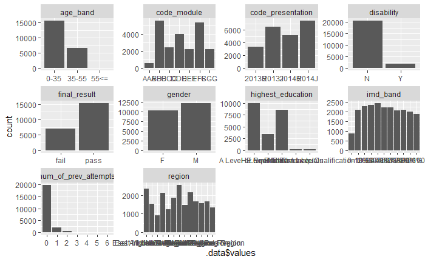

```r
categorical_data_long <- pivot_longer(categorical_data,
                                      cols = -.data$id_student,
                                      names_to = "variables",
                                      values_to = "values",
                                      )

ggplot(categorical_data_long, aes(x = .data$values)) + geom_bar() + facet_wrap(~variables, scales = "free")
```

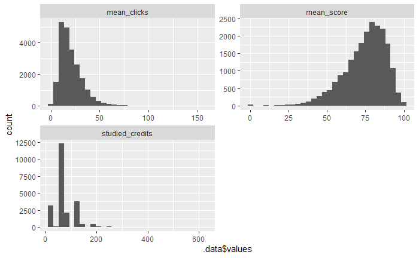

```r
continuous_data_long <- pivot_longer(continuous_data,
                                      cols = -.data$id_student,
                                      names_to = "variables",
                                      values_to = "values",
                                      )

#Individual plots to adjust bin width, then grid them together
ggplot(continuous_data_long, aes(x = .data$values)) + geom_histogram() + facet_wrap(~variables, scales = "free", ncol = 2)
```

- Visualize relationships between variables for insight

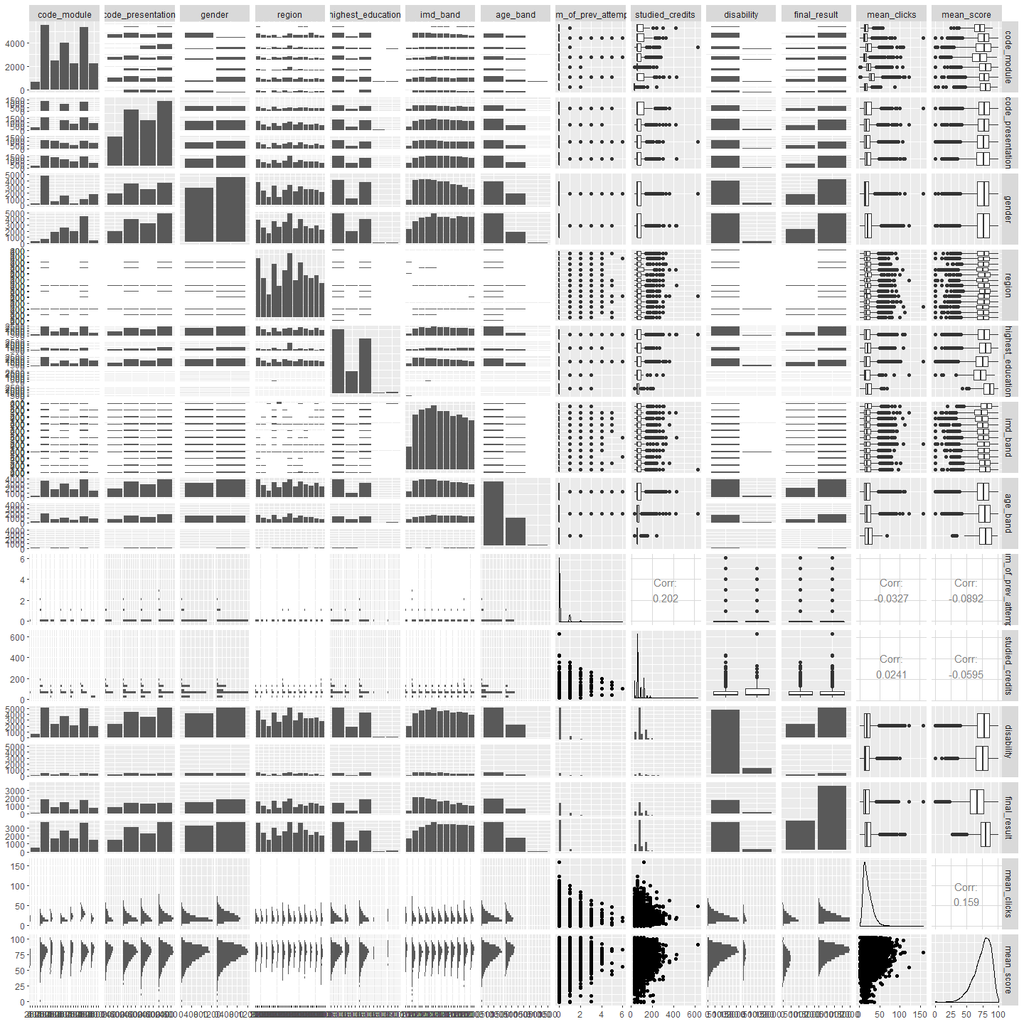

```r
joined_data %>%
  select(-id_student) %>%
  ggpairs()
```

### Create a Validation Set

- Split your data into two new datasets, `TRAINING` and `TEST`, by **randomly** selecting 25% of the students for the `TEST` set

```r
partition_index <- createDataPartition(joined_data$final_result,
                                       p = 0.75,
                                       list = FALSE
                                       )

TRAINING <- joined_data[partition_index,]
TEST <- joined_data[-partition_index,]
```

### Model Training

- Install the `caret` package
- You will be allocated one of the following models to test:

  CART (`RPART`), Conditional Inference Trees (`party`), Naive Bayes (`naivebayes`), Logistic Regression (`gpls`)
- Using the `trainControl` command in the `caret` package create a 10-fold cross-validation harness:  
  `control <- trainControl(method="cv", number=10)`

```r
control <- trainControl(method = "cv", number = 10, savePredictions = "all")
```

```r
TRAINING <- select(TRAINING, -.data$id_student)
TEST <- select(TEST, -.data$id_student)
```

- Using the standard caret syntax fit your model and measure accuracy:  
  `fit <- train(final_result~., data=TRAINING, method=YOUR MODEL, metric="accuracy", trControl=control)`

```r
# The original data has missing values that have not been addressed. However,
# rpart handles missing data on its own - see https://bit.ly/2HnW0Wa and
# https://bit.ly/39AQ8Vv for explanation of how it does this using surrogate
# splits.

# Using surrogate splits is not elegant, but is more conservative than
# filling in missing values (particularly for imd_band, which I don't even
# understand), so I'm letting that happen for now...

set.seed(1234)
fit <- train(final_result ~ .,
             data = TRAINING,
             method = "rpart",
             preProcess = c("center", "scale"),
             metric = "Accuracy",
             trControl = control,
             na.action = na.pass
             )
```

- Generate a summary of your results and create a visualization of the accuracy scores for your ten trials

```r
fit$resample
```

| Accuracy | Kappa | Resample |
| --- | --- | --- |
| 0.7657551 | 0.3775215 | Fold02 |
| 0.7373737 | 0.2946822 | Fold01 |
| 0.7278669 | 0.2974602 | Fold03 |
| 0.7449465 | 0.3100084 | Fold06 |
| 0.7397504 | 0.3060003 | Fold05 |
| 0.7391563 | 0.2696042 | Fold04 |
| 0.7296494 | 0.2647882 | Fold07 |
| 0.7456922 | 0.3145855 | Fold10 |
| 0.7338087 | 0.3008516 | Fold09 |
| 0.7439097 | 0.3085476 | Fold08 |

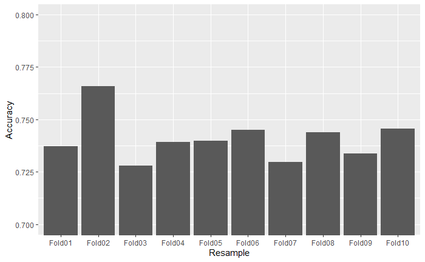

```r
ggplot(fit$resample, aes(x = Resample, y = Accuracy)) +
  geom_col() +
  coord_cartesian(ylim = c(0.70, 0.80))
```

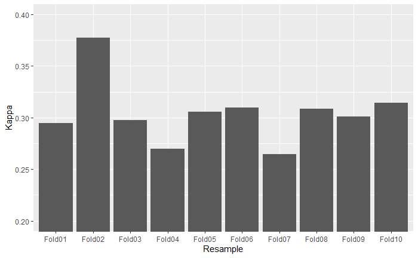

```r
ggplot(fit$resample, aes(x = Resample, y = Kappa)) +
  geom_col() +
  coord_cartesian(ylim = c(0.20, 0.40))
```

### Model Testing

- Use the `predict` function to test your model  
  `predictions <- predict(fit, TEST)`
- Generate a confusion matrix for your model test  
  `confusionMatrix(predictions, TEST$final_result)`

```r
predictions <- predict(fit, newdata = TEST, na.action = na.pass)
confusionMatrix(predictions, reference = TEST$final_result)
```

```
Confusion Matrix and Statistics

          Reference
Prediction fail pass
      fail  549  237
      pass 1214 3609

               Accuracy : 0.7413
                 95% CI : (0.7296, 0.7527)
    No Information Rate : 0.6857
    P-Value [Acc > NIR] : < 2.2e-16

                  Kappa : 0.2939

 Mcnemar's Test P-Value : < 2.2e-16

            Sensitivity : 0.31140
            Specificity : 0.93838
         Pos Pred Value : 0.69847
         Neg Pred Value : 0.74829
             Prevalence : 0.31432
         Detection Rate : 0.09788
   Detection Prevalence : 0.14013
      Balanced Accuracy : 0.62489

       'Positive' Class : fail
```

- Make any tweaks to your model to try to improve its performance

```r
# 3 things that may want to try:
# Try grouping highest education into a binary variable - university or not,
# or A levels or not

# Could also try recoding the NA values as mean values and seeing if that
# improves performance over using the surrogate splits

# Try removing code presentation which may be noise - when you do the
# module should not affect how well you do it
```